# Case study

Typical actions you perform on your data:

- Import
- Explore
- Visualize
- Model
- Report

```r
# Prepare R session
setwd("~/courses/r-workshop")
```

## Import

- R can deal with many sources, online and offline
- Dedicated application-specific packages (DBs, excel, text files)

```r
# read one part from database
# install.packages(RSQLite)
library(RSQLite)
con <- dbConnect(SQLite(), "omdb.db")
dbListTables(con)
```

```
## [1] "omdb"
```

```r
omdb <- dbReadTable(con, "omdb")

# read.csv is a built-in function
tomatoes <- read.csv("rotten_tomatoes.csv", header = TRUE)
```

## Explore

Get a first feel for your data: `summary()`, `head()`, `tail()`, `names()`.

```r
# explore omdb
names(omdb)
```

```
##  [1] "ID"          "imdbID"      "Title"       "Year"        "Rating"
##  [6] "Runtime"     "Genre"       "Released"    "Director"    "Writer"
## [11] "Cast"        "Metacritic"  "imdbRating"  "imdbVotes"   "Language"
## [16] "Country"     "Awards"      "lastUpdated" "Oscars"
```

```r
head(omdb)
```

```
##      ID    imdbID                                            Title Year
## 1  4972 tt0004972                            The Birth of a Nation 1915
## 2  6206 tt0006206                                     Les vampires 1915
## 3  6864 tt0006864 Intolerance: Love's Struggle Throughout the Ages 1916
## 4  9470 tt0009470                                     Over the Top 1918
## 5  9968 tt0009968   Broken Blossoms or The Yellow Man and the Girl 1919
## 6 10323 tt0010323                      The Cabinet of Dr. Caligari 1920
##      Rating Runtime                    Genre   Released        Director
## 1 Not Rated     165  Drama, History, Romance 1915-03-03   D.W. Griffith
## 2 Not Rated     399 Action, Adventure, Crime 1915-11-13 Louis Feuillade
## 3 Not Rated     197           Drama, History 1916-09-05   D.W. Griffith
## 4      <NA>       0               Drama, War 1918-03-31   Wilfrid North
## 5 Not Rated      90           Drama, Romance 1919-10-20   D.W. Griffith
## 6   Unrated      67                   Horror 1921-03-19    Robert Wiene
##                                                                                                                                                                                            Writer
```

[output cut: 27 more lines]

```r
summary(omdb)
```

```
##        ID             imdbID             Title                Year
##  Min.   :   4972   Length:12569       Length:12569       Min.   :1902
##  1st Qu.: 103859   Class :character   Class :character   1st Qu.:1991
##  Median : 300214   Mode  :character   Mode  :character   Median :2002
##  Mean   : 588366                                         Mean   :1996
##  3rd Qu.: 997167                                         3rd Qu.:2008
##  Max.   :3404140                                         Max.   :2014
##
##     Rating             Runtime         Genre             Released
##  Length:12569       Min.   :  0.0   Length:12569       Length:12569
##  Class :character   1st Qu.: 91.0   Class :character   Class :character
##  Mode  :character   Median :100.0   Mode  :character   Mode  :character
##                     Mean   :102.7
##                     3rd Qu.:112.0
##                     Max.   :566.0
##
##    Director            Writer              Cast             Metacritic
##  Length:12569       Length:12569       Length:12569       Min.   :  1.00
##  Class :character   Class :character   Class :character   1st Qu.: 45.00
##  Mode  :character   Mode  :character   Mode  :character   Median : 58.00
##                                                           Mean   : 56.88
##                                                           3rd Qu.: 70.00
##                                                           Max.   :100.00
##                                                           NA's   :4920
##    imdbRating     imdbVotes         Language           Country
##  Min.   :1.10   Min.   :      5   Length:12569       Length:12569
##  1st Qu.:6.00   1st Qu.:   1552   Class :character   Class :character
##  Median :6.70   Median :   5612   Mode  :character   Mode  :character
##  Mean   :6.61   Mean   :  27486
##  3rd Qu.:7.30   3rd Qu.:  22700
##  Max.   :9.30   Max.   :1187486
##  NA's   :20     NA's   :21
##     Awards          lastUpdated            Oscars
##  Length:12569       Length:12569       Min.   : 0.0000
##  Class :character   Class :character   1st Qu.: 0.0000
##  Mode  :character   Mode  :character   Median : 0.0000
##                                        Mean   : 0.1071
##                                        3rd Qu.: 0.0000
##                                        Max.   :11.0000
##
```

```r
# explore tomatoes
names(tomatoes)
```

```
##  [1] "ID"          "Image"       "Rating"      "Meter"       "Reviews"
##  [6] "Fresh"       "Rotten"      "Consensus"   "userMeter"   "userRating"
## [11] "userReviews" "DVD"         "BoxOffice"   "Production"  "Website"
## [16] "lastUpdated"
```

```r
tail(tomatoes)
```

```
##            ID Image Rating Meter Reviews Fresh Rotten Consensus userMeter
## 76425 3504824  <NA>     NA    NA       1     0      1      <NA>        NA
## 76426 3505950  <NA>     NA    NA       1     0      1      <NA>        43
## 76427 3511542  <NA>     NA    NA       3     3      0      <NA>        80
## 76428 3518988  <NA>     NA    NA       1     1      0      <NA>        NA
## 76429 3548442  <NA>     NA    NA       2     0      2      <NA>        NA
## 76430 3589450  <NA>     NA    NA       1     0      1      <NA>        NA
##       userRating userReviews DVD BoxOffice               Production
## 76425         NA          NA            NA                     <NA>
## 76426         NA          42            NA China Lion Entertainment
## 76427         NA           6            NA         China Lion Films
## 76428         NA          NA            NA                     <NA>
## 76429         NA          NA            NA                     <NA>
## 76430          4          29            NA         CJ Entertainment
##                                                              Website
## 76425                                                           <NA>
## 76426                          http://www.beijinglovestorymovie.com/
## 76427                                 http://www.thatdemonwithin.com
## 76428                                    http://live.harmontown.com/
## 76429                                                           <NA>
## 76430 http://www.cgvcinemas.com/movie/detail.asp?status=C&mov_id=243
##                         lastUpdated
## 76425 2014-02-25 03:27:24.800000000
## 76426 2014-02-13 11:44:27.180000000
## 76427 2014-03-05 17:16:01.200000000
## 76428 2014-04-03 09:10:11.390000000
## 76429 2014-03-31 03:24:10.637000000
## 76430 2014-04-03 10:09:57.423000000
```

```r
summary(tomatoes)
```

```
##        ID                Image           Rating          Meter
##  Min.   :      4   certified: 2108   Min.   : 0.00   Min.   :  0.00
##  1st Qu.:  91755   fresh    : 8226   1st Qu.: 5.00   1st Qu.: 25.00
##  Median : 269934   rotten   : 7196   Median : 6.20   Median : 50.00
##  Mean   : 549678   NA's     :58900   Mean   : 6.01   Mean   : 48.86
##  3rd Qu.: 892100                     3rd Qu.: 7.10   3rd Qu.: 73.00
##  Max.   :3589450                     Max.   :10.00   Max.   :100.00
##                                      NA's   :58900   NA's   :25146
##     Reviews          Fresh            Rotten
##  Min.   :  1.0   Min.   :  0.00   Min.   :  0.00
##  1st Qu.:  2.0   1st Qu.:  1.00   1st Qu.:  1.00
##  Median :  6.0   Median :  3.00   Median :  2.00
##  Mean   : 22.4   Mean   : 13.78   Mean   :  8.62
##  3rd Qu.: 21.0   3rd Qu.: 12.00   3rd Qu.:  6.00
##  Max.   :304.0   Max.   :292.00   Max.   :192.00
##  NA's   :44232   NA's   :44232    NA's   :44232
##                                                                                                                                                                Consensus
##                                                                                                                                                                     :  164
##  No consensus yet.                                                                                                                                                  :   57
##   Judge Dredd wants to be both a legitimate violent action flick and a parody of one, but director Danny Cannon fails to find the necessary balance to make it work.:    1
##   Kick-Ass 2 falls short in its attempt to emulate the original's unique blend of ultra-violence and ironic humor.                                                  :    1
##   Pocahontas means well, and has moments of startling beauty, but it's largely a bland, uninspired effort, with uneven plotting and an unfortunate lack of fun.     :    1
##  (Other)                                                                                                                                                            : 5557
##  NA's                                                                                                                                                               :70649
##    userMeter       userRating     userReviews               DVD
##  Min.   : 0.00   Min.   :0.000   Min.   :       1             :52420
##  1st Qu.:29.00   1st Qu.:2.900   1st Qu.:      48   2005-03-29:  134
##  Median :50.00   Median :3.400   Median :     172   2004-06-01:  108
##  Mean   :48.78   Mean   :3.299   Mean   :   34142   2005-05-31:   81
##  3rd Qu.:70.00   3rd Qu.:3.700   3rd Qu.:     990   2005-03-08:   78
##  Max.   :99.00   Max.   :5.000   Max.   :35777501   2005-04-05:   76
##  NA's   :12871   NA's   :19383   NA's   :8328       (Other)   :23533
##    BoxOffice                                    Production
##  Min.   :      181                                   :44459
##  1st Qu.:   200000   Sony Pictures Home Entertainment:  684
##  Median :  3200000   Warner Home Video               :  549
##  Mean   : 28009338   Universal Pictures              :  499
##  3rd Qu.: 32600000   Paramount Pictures              :  455
##  Max.   :760500000   (Other)                         :18582
##  NA's   :71878       NA's                            :11202
##                              Website                   lastUpdated
##                                  :44459   2012-09-30 00:00:00:12750
##  http://www.ifcfilms.com/        :   12   2012-10-01 00:00:00:10092
##  http://www.thinkfilmcompany.com/:   12   2012-10-05 00:00:00: 2743
##  http://www.ifcfilms.com         :   11   2012-09-24 00:00:00: 2525
##  http://www.strandreleasing.com  :   11   2012-09-25 00:00:00: 1648
##  (Other)                         : 9954   2012-09-23 00:00:00: 1283
##  NA's                            :21971   (Other)            :45389
```

Use the `merge()` function to merge `tomatoes` and `omdb`: one data set.

```r
# Do the merge
movies <- merge(omdb, tomatoes, by="ID")

# Check out the result
names(movies)
```

```
##  [1] "ID"            "imdbID"        "Title"         "Year"
##  [5] "Rating.x"      "Runtime"       "Genre"         "Released"
##  [9] "Director"      "Writer"        "Cast"          "Metacritic"
## [13] "imdbRating"    "imdbVotes"     "Language"      "Country"
## [17] "Awards"        "lastUpdated.x" "Oscars"        "Image"
## [21] "Rating.y"      "Meter"         "Reviews"       "Fresh"
## [25] "Rotten"        "Consensus"     "userMeter"     "userRating"
## [29] "userReviews"   "DVD"           "BoxOffice"     "Production"
## [33] "Website"       "lastUpdated.y"
```

```r
head(movies)
```

```
##      ID    imdbID                                            Title Year
## 1  4972 tt0004972                            The Birth of a Nation 1915
## 2  6206 tt0006206                                     Les vampires 1915
## 3  6864 tt0006864 Intolerance: Love's Struggle Throughout the Ages 1916
## 4  9470 tt0009470                                     Over the Top 1918
## 5  9968 tt0009968   Broken Blossoms or The Yellow Man and the Girl 1919
## 6 10323 tt0010323                      The Cabinet of Dr. Caligari 1920
##    Rating.x Runtime                    Genre   Released        Director
## 1 Not Rated     165  Drama, History, Romance 1915-03-03   D.W. Griffith
## 2 Not Rated     399 Action, Adventure, Crime 1915-11-13 Louis Feuillade
## 3 Not Rated     197           Drama, History 1916-09-05   D.W. Griffith
## 4      <NA>       0               Drama, War 1918-03-31   Wilfrid North
## 5 Not Rated      90           Drama, Romance 1919-10-20   D.W. Griffith
## 6   Unrated      67                   Horror 1921-03-19    Robert Wiene
##                                                                                                                                                                                            Writer
```

[output cut: 55 more lines]

```r
summary(movies)
```

```
##        ID             imdbID             Title                Year
##  Min.   :   4972   Length:12569       Length:12569       Min.   :1902
##  1st Qu.: 103859   Class :character   Class :character   1st Qu.:1991
##  Median : 300214   Mode  :character   Mode  :character   Median :2002
##  Mean   : 588366                                         Mean   :1996
##  3rd Qu.: 997167                                         3rd Qu.:2008
##  Max.   :3404140                                         Max.   :2014
##
##    Rating.x            Runtime         Genre             Released
##  Length:12569       Min.   :  0.0   Length:12569       Length:12569
##  Class :character   1st Qu.: 91.0   Class :character   Class :character
##  Mode  :character   Median :100.0   Mode  :character   Mode  :character
##                     Mean   :102.7
##                     3rd Qu.:112.0
##                     Max.   :566.0
##
##    Director            Writer              Cast             Metacritic
##  Length:12569       Length:12569       Length:12569       Min.   :  1.00
##  Class :character   Class :character   Class :character   1st Qu.: 45.00
##  Mode  :character   Mode  :character   Mode  :character   Median : 58.00
##                                                           Mean   : 56.88
##                                                           3rd Qu.: 70.00
##                                                           Max.   :100.00
##                                                           NA's   :4920
##    imdbRating     imdbVotes         Language           Country
##  Min.   :1.10   Min.   :      5   Length:12569       Length:12569
##  1st Qu.:6.00   1st Qu.:   1552   Class :character   Class :character
##  Median :6.70   Median :   5612   Mode  :character   Mode  :character
##  Mean   :6.61   Mean   :  27486
##  3rd Qu.:7.30   3rd Qu.:  22700
##  Max.   :9.30   Max.   :1187486
##  NA's   :20     NA's   :21
##     Awards          lastUpdated.x          Oscars              Image
##  Length:12569       Length:12569       Min.   : 0.0000   certified:2099
##  Class :character   Class :character   1st Qu.: 0.0000   fresh    :5404
##  Mode  :character   Mode  :character   Median : 0.0000   rotten   :5066
##                                        Mean   : 0.1071
##                                        3rd Qu.: 0.0000
##                                        Max.   :11.0000
##
```

[output cut: 33 more lines]

```
##  Min.   :      382   Universal Pictures              : 367
##  1st Qu.:   200000   Warner Bros. Pictures           : 367
##  Median :  5100000   Sony Pictures Home Entertainment: 349
##  Mean   : 30245553   Paramount Pictures              : 331
##  3rd Qu.: 36000000   20th Century Fox                : 317
##  Max.   :760500000   (Other)                         :9734
##  NA's   :8380        NA's                            :1104
##                              Website                 lastUpdated.y
##                                  :  14   2014-02-04 00:00:00:   21
##  http://www.thinkfilmcompany.com/:  12   2014-02-02 00:00:00:    4
##  http://www.ifcfilms.com         :  10   2014-01-12 00:00:00:    3
##  http://www.ifcfilms.com/        :   8   2014-01-30 00:00:00:    3
##  http://www.strandreleasing.com  :   8   2014-02-06 00:00:00:    3
##  (Other)                         :6709   2014-02-08 00:00:00:    3
##  NA's                            :5808   (Other)            :12532
```

There is still some cleaning needed!

```r
# let's work with imdbRating and userRating
names(movies)[names(movies) == "userRating"] <- "rottenRating"
names(movies)[names(movies) == "userReviews"] <- "rottenVotes"

# Remove NA rating info, before it messes up our analyses
row_misses_info <-  is.na(movies$imdbVotes) | is.na(movies$rottenVotes) | is.na(movies$imdbRating) | is.na(movies$rottenRating)
summary(row_misses_info)
```

```
##    Mode   FALSE    TRUE    NA's
## logical   12339     230       0
```

```r
movies <- movies[!row_misses_info, ]

# Remove movies that haven't got 10000 votes for both imdb and rotten tomatoes
movies <- movies[movies$imdbVotes > 10000 & movies$rottenVotes > 10000, ]

# Keep only columns that we will be using later on
cols_to_keep <- c("Title", "Year", "Runtime", "imdbRating", "imdbVotes", "rottenRating", "rottenVotes")
movies <- movies[cols_to_keep]

# Check out the result
summary(movies)
```

```
##     Title                Year         Runtime        imdbRating
##  Length:4302        Min.   :1920   Min.   : 16.0   Min.   :1.600
##  Class :character   1st Qu.:1992   1st Qu.: 95.0   1st Qu.:6.000
##  Mode  :character   Median :2002   Median :105.0   Median :6.800
##                     Mean   :1998   Mean   :108.6   Mean   :6.674
##                     3rd Qu.:2008   3rd Qu.:118.0   3rd Qu.:7.400
##                     Max.   :2014   Max.   :271.0   Max.   :9.300
##    imdbVotes        rottenRating    rottenVotes
##  Min.   :  10003   Min.   :1.600   Min.   :   10011
##  1st Qu.:  21014   1st Qu.:3.100   1st Qu.:   33300
##  Median :  39562   Median :3.400   Median :   67432
##  Mean   :  72915   Mean   :3.363   Mean   :  517902
##  3rd Qu.:  82540   3rd Qu.:3.700   3rd Qu.:  234670
##  Max.   :1187486   Max.   :4.500   Max.   :35777501
```

```r
# install.packages(dplyr)
library(dplyr)
movies <- movies %>%
  mutate(Votes = imdbVotes + rottenVotes,
         Rating = (imdbVotes*imdbRating + rottenVotes*2*rottenRating)/Votes)
```

Let’s do some first exploratory queries:

```r
# Top rated movies
movies %>% select(Title, Rating) %>% arrange(desc(Rating)) %>% head(15)
```

```
##                              Title   Rating
## 1         The Shawshank Redemption 9.088329
## 2                    The Godfather 9.013235
## 3           The Godfather: Part II 8.886579
## 4                  The Dark Knight 8.878644
## 5                    Seven Samurai 8.866020
## 6                 Schindler's List 8.779589
## 7                     12 Angry Men 8.775105
## 8                      City Lights 8.726726
## 9                       Goodfellas 8.710305
## 10    Once Upon a Time in the West 8.671668
## 11                    Pulp Fiction 8.670121
## 12                           Senna 8.665120
## 13                     City of God 8.660982
## 14 One Flew Over the Cuckoo's Nest 8.657051
## 15                       Inception 8.651352
```

```r
# Most voted movies
movies %>% select(Title, Votes) %>% arrange(desc(Votes)) %>% head(15)
```

```
##                                                             Title    Votes
## 1                                                         Titanic 36342891
## 2                   The Lord of the Rings: The Return of the King 35498214
## 3                                                       Gladiator 34772082
## 4                                                         Shrek 2 34443610
## 5                             Harry Potter and the Goblet of Fire 34419990
## 6  The Chronicles of Narnia: The Lion, the Witch and the Wardrobe 34308495
## 7                                                      The Matrix 34142466
## 8                                                    American Pie 34022132
## 9                    Star Wars: Episode III - Revenge of the Sith 34019524
## 10                                                      King Kong 34006851
## 11                                                   Finding Nemo 33786280
## 12                                               Mr. & Mrs. Smith 33685508
## 13         Pirates of the Caribbean: The Curse of the Black Pearl 33680018
## 14                                                          Rocky 33632583
## 15                                     Ace Ventura: Pet Detective 33349618
```

## Visualize

How are ratings distributed?

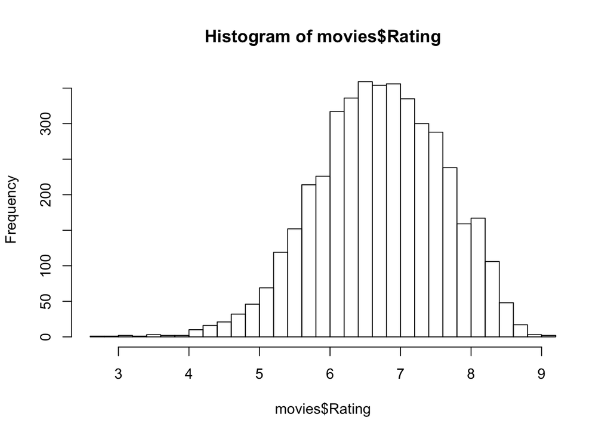

```r
hist(movies$Rating, breaks = 25)
```

Compare rotten ratings to imdb ratings

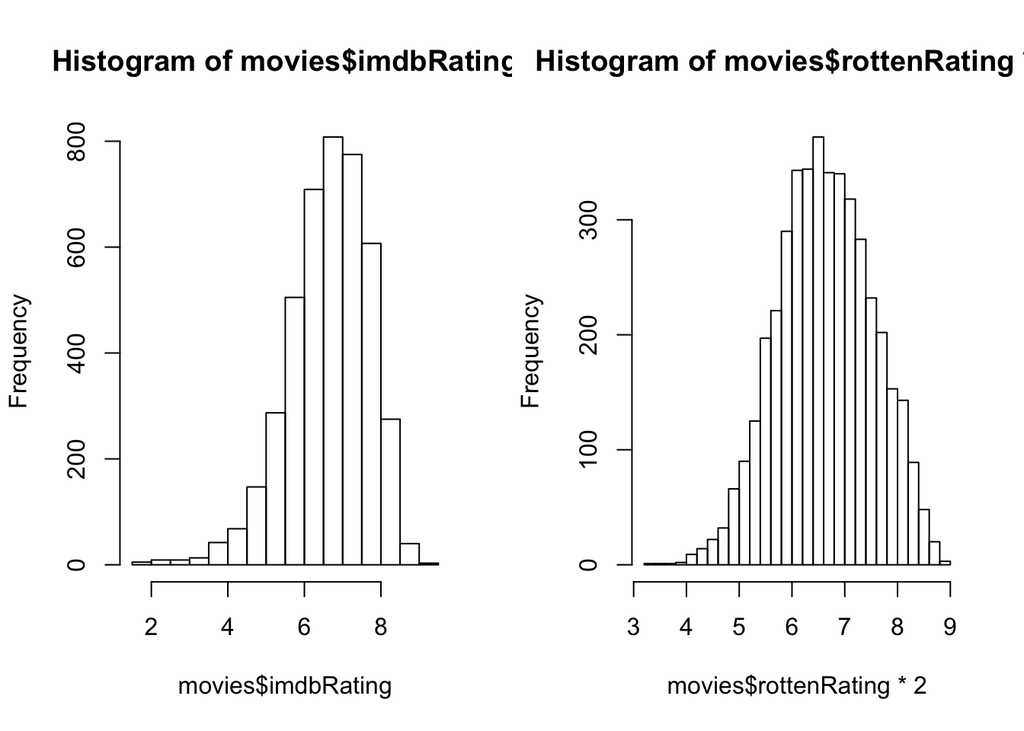

```r
par(mfrow = c(1, 2))
hist(movies$imdbRating, breaks = 25)
hist(movies$rottenRating*2, breaks = 25)
```

```r
par(mfrow=c(1,1))
```

## Model

Is there a correlation between a movie’s runtime and its rating?

```r
cor(movies$Rating, movies$Runtime)
```

```
## [1] 0.3172842
```

Let’s use the `ggvis` package to plot a non-linear model to explain Rating based on Runtime:

```r
library(ggvis)
movies %>% ggvis(~Runtime, ~Rating) %>% layer_points() %>% layer_smooths(se = TRUE)
```

[output not shown]

## Report

- Reproducible reporting: R Markdown
- R code chunks inside a document
- Uses Markdown syntax

## Powerful packages

- `dplyr` & `data.table` for data manipulation
- `ggvis` for visualization
- Free DataCamp Trial: www.datacamp.com/demo